# Estudios de Informática, Multimedia y Telecomunicaciones

# Minería de datos: PRA1 - Selección y preparación de un juego de datos

Autor: Tim Thorp

Diciembre 2023

# 1 Objetivo analítico

En este estudio sobre retrasos de vuelos en Estados Unidos, abordamos un problema de clasificación con el objetivo de predecir si un vuelo se retrasará más de 15 minutos, considerándolo como una variable binaria. Utilizamos variables como los aeropuertos de origen y destino, la aerolínea, el día de la semana, la hora programada de salida y la distancia del vuelo.

Hemos seleccionado la precisión como nuestra métrica principal, con un objetivo de alcanzar al menos un 80% de precisión. Este análisis busca no solo predecir retrasos, sino también identificar los factores más influyentes y analizar patrones temporales, así como diferencias entre aerolíneas y rutas. La metodología incluye el uso de modelos de clasificación, como la regresión logística y los árboles de decisión, evaluando su rendimiento mediante la división de los datos en conjuntos de entrenamiento y prueba, y mediante la validación cruzada.

Este proyecto no solo ayudará a las aerolíneas y a los aeropuertos en su planificación operativa, sino que también mejorará la experiencia del cliente al proporcionar información sobre los retrasos en los vuelos. La primera fase del estudio se centra en un análisis exploratorio del conjunto de datos, seguido de tareas de limpieza y acondicionamiento. Además, aplicaremos métodos de discretización y realizaremos un estudio utilizando SVD para la reducción de la dimensionalidad, preparando así los datos para el modelado en la siguiente fase del estudio.

# 2 Juego de datos

Hemos seleccionado nuestro conjunto de datos desde el *Bureau of Transportation Statistics* del Departamento de Transporte de Estados Unidos. La [página web](https://www.transtats.bts.gov/DL_SelectFields.aspx?gnoyr_VQ=FGJ&QO_fu146_anzr=b0-gvzr) ofrece más de 100 variables, pero nos centramos en las más relevantes para nuestro estudio.

Debido a limitaciones de hardware, solo analizaremos los datos del último mes disponible, septiembre de 2023, que contiene 569,338 observaciones (vuelos). Este enfoque limita la generalización del estudio, pero es necesario para manejar el volumen de datos con nuestros recursos actuales.

El conjunto de datos seleccionado incluye 9 variables numéricas, 5 categóricas y 3 binarias. Las variables son:

- **DAY_OF_WEEK**: Día de la semana en que se realiza el vuelo, en formato numérico (1 = lunes, 7 = domingo). Se tratará como categórica.
- **FL_DATE**: Fecha del vuelo.
- **OP_UNIQUE_CARRIER**: Código de identificación único para la aerolínea operadora.
- **ORIGIN**: Código del aeropuerto de origen.
- **DEST**: Código del aeropuerto de destino.
- **CRS_DEP_TIME**: Hora de salida programada (formato hhmm).
- **DEP_TIME**: Hora de salida real (formato hhmm).
- **DEP_DELAY_NEW**: Retraso en la salida (en minutos).
- **CRS_ARR_TIME**: Hora de llegada programada (formato hhmm).
- **ARR_TIME**: Hora de llegada real (formato hhmm).
- **ARR_DELAY_NEW**: Retraso en la llegada (en minutos).
- **ARR_DEL15**: Indicador de si el vuelo llegó con más de 15 minutos de retraso (1 = sí, 0 = no).
- **CANCELLED**: Indicador de si el vuelo fue cancelado (1 = sí, 0 = no).
- **DIVERTED**: Indicador de si el vuelo fue desviado (1 = sí, 0 = no).
- **CRS_ELAPSED_TIME**: Tiempo total estimado del vuelo (en minutos).
- **ACTUAL_ELAPSED_TIME**: Tiempo total real del vuelo (en minutos).
- **DISTANCE**: Distancia del vuelo en millas.

Estas variables nos permiten aplicar algoritmos supervisados, no supervisados y reglas de asociación para un análisis detallado de los retrasos en los vuelos.

Los vuelos cancelados (`CANCELLED`) y desviados (`DIVERTED`) están fuera del ámbito de este estudio, pero utilizaremos estas variables para filtrar los datos.

Para empezar, cargamos el fichero de datos.

```r
flightData <- read.csv('../data/flightData.csv', row.names=NULL, stringsAsFactors=TRUE)
```

Primero, verificamos la estructura del conjunto de datos principal. Observamos el número de columnas y algunos ejemplos del contenido de las filas.

```r
str(flightData)
```

```
## 'data.frame':    569338 obs. of  17 variables:
##  $ DAY_OF_WEEK        : int  1 1 1 1 1 1 1 1 1 1 ...
##  $ FL_DATE            : Factor w/ 30 levels "9/1/2023 12:00:00 AM",..: 25 25 25 25 25 25 25 25 25 25 ...
##  $ OP_UNIQUE_CARRIER  : Factor w/ 15 levels "9E","AA","AS",..: 1 1 1 1 1 1 1 1 1 1 ...
##  $ ORIGIN             : Factor w/ 340 levels "ABE","ABI","ABQ",..: 1 1 1 5 5 12 12 13 15 15 ...
##  $ DEST               : Factor w/ 340 levels "ABE","ABI","ABQ",..: 21 21 21 21 21 21 21 21 99 190 ...
##  $ CRS_DEP_TIME       : int  654 1242 1727 735 1405 610 1620 1015 1245 706 ...
##  $ DEP_TIME           : int  649 1237 1717 725 1400 609 1636 1010 1237 701 ...
##  $ DEP_DELAY_NEW      : num  0 0 0 0 0 0 16 0 0 0 ...
##  $ CRS_ARR_TIME       : int  900 1450 1938 848 1512 859 1906 1123 1428 803 ...
##  $ ARR_TIME           : int  842 1431 1905 820 1454 904 1913 1100 1411 759 ...
##  $ ARR_DELAY_NEW      : num  0 0 0 0 0 5 7 0 0 0 ...
##  $ ARR_DEL15          : num  0 0 0 0 0 0 0 0 0 0 ...
##  $ CANCELLED          : num  0 0 0 0 0 0 0 0 0 0 ...
##  $ DIVERTED           : num  0 0 0 0 0 0 0 0 0 0 ...
##  $ CRS_ELAPSED_TIME   : num  126 128 131 73 67 109 106 68 103 57 ...
##  $ ACTUAL_ELAPSED_TIME: num  113 114 108 55 54 115 97 50 94 58 ...
##  $ DISTANCE           : num  692 692 692 145 145 500 500 143 489 136 ...
```

Vemos que contamos con **17 variables** y **569.338** registros.

La variable `DAY_OF_WEEK` está actualmente clasificada como de tipo entero. A pesar de su naturaleza numérica, sería más adecuado considerarla como categórica (factor) en el contexto de este estudio.

La variable `FL_DATE` consta de 30 niveles, lo que coincide con el número de días en septiembre. El formato de la fecha es MM/DD/YYYY.

Hay 15 aerolíneas distintas (`OP_UNIQUE_CARRIER`) y 340 aeropuertos (`ORIGIN` y `DEST`).

A continuación, miramos el resumen de los datos.

```r
summary(flightData)
```

```
##   DAY_OF_WEEK                     FL_DATE       OP_UNIQUE_CARRIER
##  Min.   :1.000   9/21/2023 12:00:00 AM: 20358   WN     :117870
##  1st Qu.:2.000   9/28/2023 12:00:00 AM: 20341   DL     : 81701
##  Median :4.000   9/22/2023 12:00:00 AM: 20268   AA     : 76972
##  Mean   :4.066   9/18/2023 12:00:00 AM: 20264   UA     : 62591
##  3rd Qu.:6.000   9/25/2023 12:00:00 AM: 20246   OO     : 59245
##  Max.   :7.000   9/29/2023 12:00:00 AM: 20242   YX     : 24839
##                  (Other)              :447619   (Other):146120
##      ORIGIN            DEST         CRS_DEP_TIME     DEP_TIME
##  ATL    : 28344   ATL    : 28359   Min.   :   4   Min.   :   1
##  DEN    : 24738   DEN    : 24727   1st Qu.: 910   1st Qu.: 911
##  DFW    : 24533   DFW    : 24531   Median :1319   Median :1320
##  ORD    : 22384   ORD    : 22368   Mean   :1328   Mean   :1329
##  CLT    : 16175   CLT    : 16168   3rd Qu.:1734   3rd Qu.:1741
##  LAX    : 16152   LAX    : 16152   Max.   :2359   Max.   :2400
##  (Other):437012   (Other):437033                  NA's   :6617
##  DEP_DELAY_NEW      CRS_ARR_TIME     ARR_TIME    ARR_DELAY_NEW
##  Min.   :   0.00   Min.   :   1   Min.   :   1   Min.   :   0.0
##  1st Qu.:   0.00   1st Qu.:1105   1st Qu.:1047   1st Qu.:   0.0
##  Median :   0.00   Median :1516   Median :1501   Median :   0.0
##  Mean   :  14.19   Mean   :1492   Mean   :1463   Mean   :  14.1
##  3rd Qu.:   7.00   3rd Qu.:1920   3rd Qu.:1915   3rd Qu.:   7.0
##  Max.   :2360.00   Max.   :2359   Max.   :2400   Max.   :2367.0
##  NA's   :6618                     NA's   :7145   NA's   :8451
##    ARR_DEL15       CANCELLED         DIVERTED        CRS_ELAPSED_TIME
##  Min.   :0.000   Min.   :0.0000   Min.   :0.000000   Min.   : 24
##  1st Qu.:0.000   1st Qu.:0.0000   1st Qu.:0.000000   1st Qu.: 91
##  Median :0.000   Median :0.0000   Median :0.000000   Median :126
##  Mean   :0.187   Mean   :0.0124   Mean   :0.002447   Mean   :144
##  3rd Qu.:0.000   3rd Qu.:0.0000   3rd Qu.:0.000000   3rd Qu.:174
##  Max.   :1.000   Max.   :1.0000   Max.   :1.000000   Max.   :670
##  NA's   :8451
##  ACTUAL_ELAPSED_TIME    DISTANCE
##  Min.   : 17.0       Min.   :  21.0
##  1st Qu.: 86.0       1st Qu.: 393.0
##  Median :121.0       Median : 668.0
##  Mean   :138.6       Mean   : 825.5
##  3rd Qu.:169.0       3rd Qu.:1056.0
##  Max.   :723.0       Max.   :5095.0
##  NA's   :8451
```

Todos los valores numéricos están dentro del rango esperado, pero existen numerosos valores `NA` en campos como `DEP_TIME`, `DEP_DELAY_NEW`, `ARR_TIME`, `ARR_DELAY_NEW`, `ARR_DEL15` y `ACTUAL_ELAPSED_TIME`. Estos podrían corresponder a vuelos cancelados (`CANCELLED`) o desviados (`DIVERTED`).

Dado que la media de `ARR_DEL15` es igual a 0.187, sabemos que el 18.7% de los vuelos en nuestro dataset se retrasaron 15 minutos o más.

# 3 Limpieza

El siguiente paso será la limpieza de datos. Primero cambiamos la variable `DAY_OF_WEEK` a tipo factor.

```r
flightData$DAY_OF_WEEK <- factor(flightData$DAY_OF_WEEK, levels = c(1, 2, 3, 4, 5, 6, 7),
                           labels = c("lunes", "martes", "miércoles", "jueves",
                                      "viernes", "sábado", "domingo"))

summary(flightData$DAY_OF_WEEK)
```

```
##     lunes    martes miércoles    jueves   viernes    sábado   domingo
##     80423     73166     73919     80529    100284     84214     76803
```

El viernes registró la mayor cantidad de vuelos en nuestro conjunto de datos, en parte debido a que septiembre de 2023 contó con 5 viernes y 5 sábados, mientras que los otros días de la semana solo tuvieron 4.

Cambiamos el formato de `FL_DATE` a tipo `Date` (YYYY-MM-DD) y quitamos la parte de hora:

```r
flightData$FL_DATE <- as.Date(flightData$FL_DATE, format = "%m/%d/%Y %I:%M:%S %p")
summary(flightData$FL_DATE)
```

```
##         Min.      1st Qu.       Median         Mean      3rd Qu.         Max.
## "2023-09-01" "2023-09-08" "2023-09-16" "2023-09-15" "2023-09-23" "2023-09-30"
```

Confirmamos que todos los vuelos están comprendidos entre el 1 y 30 de septiembre.

Añadimos los nombres de las aerolíneas para facilitar la interpretación de `OP_UNIQUE_CARRIER`.

```r
carrier_names <- c("9E" = "Endeavor Air",
                   "AA" = "American Airlines",
                   "AS" = "Alaska Airlines",
                   "B6" = "JetBlue Airways",
                   "DL" = "Delta Air Lines",
                   "F9" = "Frontier Airlines",
                   "G4" = "Allegiant Air",
                   "HA" = "Hawaiian Airlines",
                   "MQ" = "Envoy Air",
                   "NK" = "Spirit Airlines",
                   "OH" = "PSA Airlines",
                   "OO" = "SkyWest Airlines",
                   "UA" = "United Airlines",
                   "WN" = "Southwest Airlines",
                   "YX" = "Republic Airways")

levels(flightData$OP_UNIQUE_CARRIER) <- carrier_names
summary(flightData$OP_UNIQUE_CARRIER)
```

```
##       Endeavor Air  American Airlines    Alaska Airlines    JetBlue Airways
##              17319              76972              21426              21412
##    Delta Air Lines  Frontier Airlines      Allegiant Air  Hawaiian Airlines
##              81701              16353               6892               6718
##          Envoy Air    Spirit Airlines       PSA Airlines   SkyWest Airlines
##              18789              21036              16175              59245
##    United Airlines Southwest Airlines   Republic Airways
##              62591             117870              24839
```

Borramos los vuelos desviados y cancelados del dataset.

```r
# Borramos las filas con vuelos desviados o cancelados
flightData <- flightData[!(flightData$CANCELLED == 1 | flightData$DIVERTED == 1), ]

# Borramos las columnas vacías
flightData$CANCELLED <- NULL
flightData$DIVERTED <- NULL

# Mostramos el dataset actualizado
str(flightData)
```

```
## 'data.frame':    560887 obs. of  15 variables:
##  $ DAY_OF_WEEK        : Factor w/ 7 levels "lunes","martes",..: 1 1 1 1 1 1 1 1 1 1 ...
##  $ FL_DATE            : Date, format: "2023-09-04" "2023-09-04" ...
##  $ OP_UNIQUE_CARRIER  : Factor w/ 15 levels "Endeavor Air",..: 1 1 1 1 1 1 1 1 1 1 ...
##  $ ORIGIN             : Factor w/ 340 levels "ABE","ABI","ABQ",..: 1 1 1 5 5 12 12 13 15 15 ...
##  $ DEST               : Factor w/ 340 levels "ABE","ABI","ABQ",..: 21 21 21 21 21 21 21 21 99 190 ...
##  $ CRS_DEP_TIME       : int  654 1242 1727 735 1405 610 1620 1015 1245 706 ...
##  $ DEP_TIME           : int  649 1237 1717 725 1400 609 1636 1010 1237 701 ...
##  $ DEP_DELAY_NEW      : num  0 0 0 0 0 0 16 0 0 0 ...
##  $ CRS_ARR_TIME       : int  900 1450 1938 848 1512 859 1906 1123 1428 803 ...
##  $ ARR_TIME           : int  842 1431 1905 820 1454 904 1913 1100 1411 759 ...
##  $ ARR_DELAY_NEW      : num  0 0 0 0 0 5 7 0 0 0 ...
##  $ ARR_DEL15          : num  0 0 0 0 0 0 0 0 0 0 ...
##  $ CRS_ELAPSED_TIME   : num  126 128 131 73 67 109 106 68 103 57 ...
##  $ ACTUAL_ELAPSED_TIME: num  113 114 108 55 54 115 97 50 94 58 ...
##  $ DISTANCE           : num  692 692 692 145 145 500 500 143 489 136 ...
```

El dataset se ha reducido a **15 variables** y **560.887** registros.

Al borrar los vuelos cancelados y desviados del dataset, las columnas `DEP_TIME`, `DEP_DELAY_NEW`, `ARR_TIME`, `ARR_DELAY_NEW`, `ARR_DEL15` y `ACTUAL_ELAPSED_TIME` ya no presentan valores NA:

```r
colSums(is.na(flightData))
```

```
##         DAY_OF_WEEK             FL_DATE   OP_UNIQUE_CARRIER              ORIGIN
##                   0                   0                   0                   0
##                DEST        CRS_DEP_TIME            DEP_TIME       DEP_DELAY_NEW
##                   0                   0                   0                   0
##        CRS_ARR_TIME            ARR_TIME       ARR_DELAY_NEW           ARR_DEL15
##                   0                   0                   0                   0
##    CRS_ELAPSED_TIME ACTUAL_ELAPSED_TIME            DISTANCE
##                   0                   0                   0
```

Y tampoco hay cadenas vacías:

```r
colSums(flightData=="")
```

```
##         DAY_OF_WEEK             FL_DATE   OP_UNIQUE_CARRIER              ORIGIN
##                   0                  NA                   0                   0
##                DEST        CRS_DEP_TIME            DEP_TIME       DEP_DELAY_NEW
##                   0                   0                   0                   0
##        CRS_ARR_TIME            ARR_TIME       ARR_DELAY_NEW           ARR_DEL15
##                   0                   0                   0                   0
##    CRS_ELAPSED_TIME ACTUAL_ELAPSED_TIME            DISTANCE
##                   0                   0                   0
```

# 4 Análisis exploratorio

Vamos a crear gráficos y describir los valores para obtener una visión general de estos atributos y para realizar una primera aproximación a los datos.

## 4.1 Análisis temporal

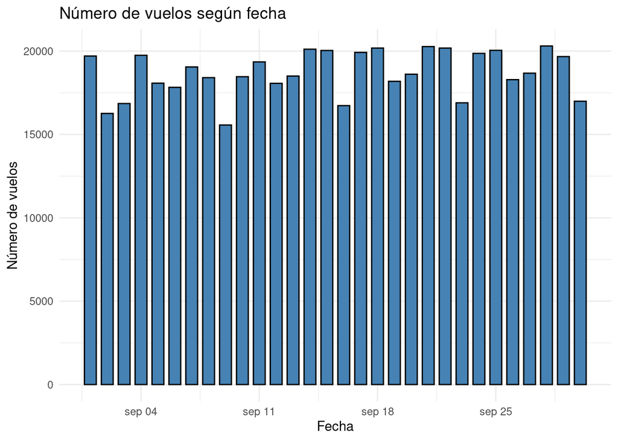

```r
library(ggplot2)

ggplot(flightData, aes(x = FL_DATE)) +
  geom_bar(fill = "steelblue", color = "black", width = 0.7)  +
  labs(x = "Fecha", y = "Número de vuelos",
       title = "Número de vuelos según fecha") +
  theme_minimal()
```

El gráfico revela una variación en el número de vuelos a lo largo del mes. Notamos una disminución en la cantidad de vuelos en ciertas fechas: los días 2, 9, 16, 23 y 30 de septiembre. Todas estas fechas corresponden a sábados.

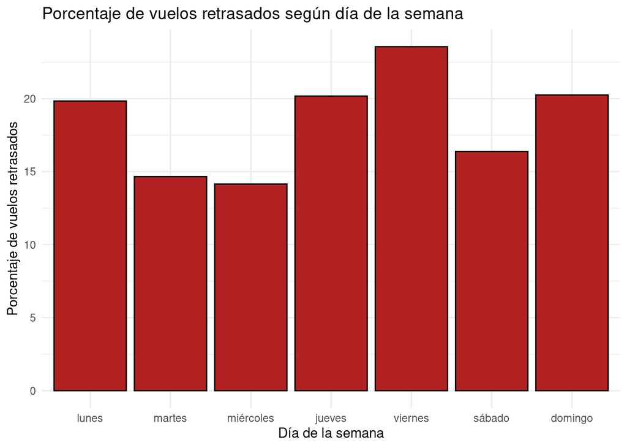

```r
library(dplyr)

percentage_delays <- flightData %>%
  group_by(DAY_OF_WEEK) %>%
  summarise(Percentage_Delayed = mean(ARR_DEL15, na.rm = TRUE) * 100)

ggplot(percentage_delays, aes(x = DAY_OF_WEEK, y = Percentage_Delayed)) +
  geom_bar(stat = "identity", fill = "firebrick", color = "black") +
  labs(x = "Día de la semana", y = "Porcentaje de vuelos retrasados",
       title = "Porcentaje de vuelos retrasados según día de la semana") +
  theme_minimal()
```

## 4.2 Análisis por aerolínea

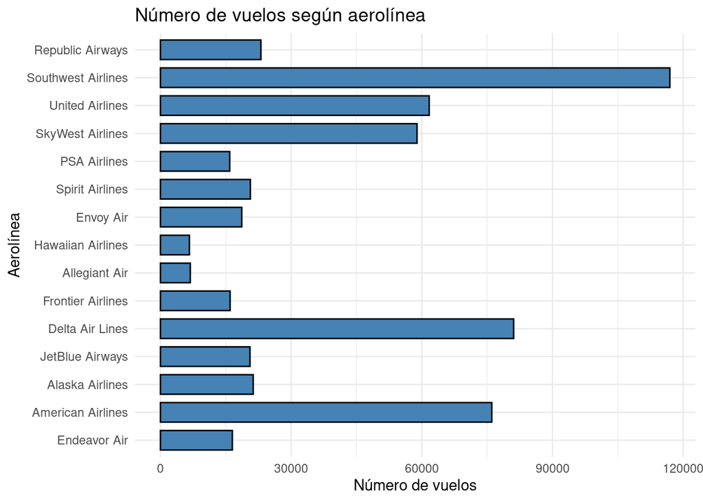

```r
ggplot(flightData, aes(y = OP_UNIQUE_CARRIER)) +
  geom_bar(fill = "steelblue", color = "black", width = 0.7) +
  theme_minimal() +
  labs(x = "Número de vuelos", y = "Aerolínea",
       title = "Número de vuelos según aerolínea")
```

En cuanto al volumen de vuelos, Southwest, Delta y American son las aerolíneas con mayor cantidad.

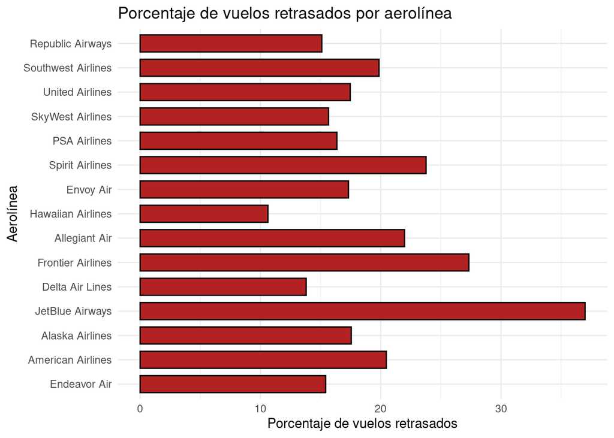

```r
percentage_delays <- flightData %>%
  group_by(OP_UNIQUE_CARRIER) %>%
  summarise(Percentage_Delayed = mean(ARR_DEL15, na.rm = TRUE) * 100)

ggplot(percentage_delays, aes(x = Percentage_Delayed, y = OP_UNIQUE_CARRIER)) +
  geom_bar(stat = "identity", fill = "firebrick", color = "black", width = 0.7) +
  labs(x = "Porcentaje de vuelos retrasados", y = "Aerolínea",
       title = "Porcentaje de vuelos retrasados por aerolínea") +
  theme_minimal()
```

El porcentaje de vuelos retrasados varía significativamente entre las aerolíneas. La aerolínea con el mayor porcentaje de retrasos es JetBlue con 37.0 %, mientras que Hawaiian Airlines muestra la menor incidencia con solo el 10.6 %.

## 4.3 Análisis por aeropuerto

Dado que nuestro dataset cuenta con 340 aeropuertos distintos, este análisis se enfoca en los diez aeropuertos con el mayor número de vuelos.

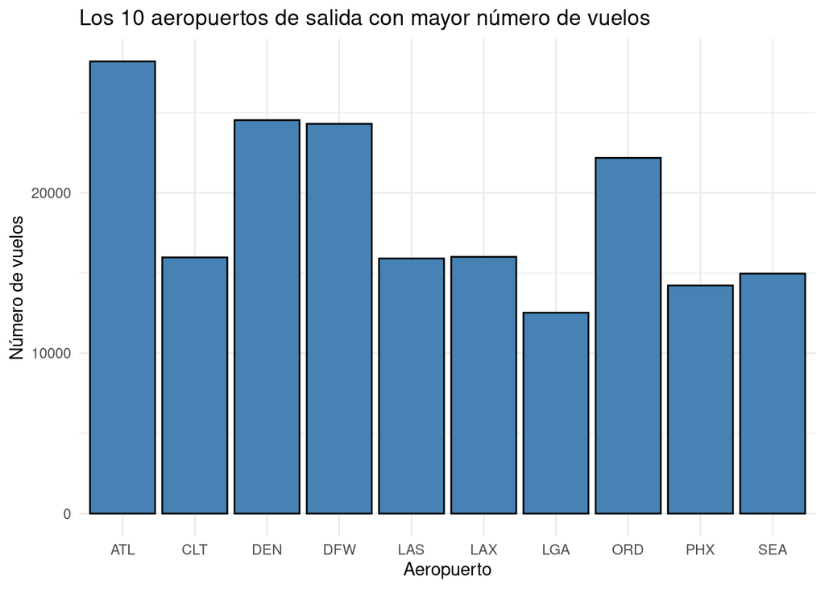

```r
top_airports <- flightData %>%
  group_by(ORIGIN) %>%
  summarise(FlightCount = n()) %>%
  arrange(desc(FlightCount)) %>%
  top_n(10, FlightCount)

ggplot(top_airports, aes(x = ORIGIN, y = FlightCount)) +
  geom_bar(stat = "identity", fill = "steelblue", color = "black") +
  theme_minimal() +
  labs(x = "Aeropuerto", y = "Número de vuelos",
       title = "Los 10 aeropuertos de salida con mayor número de vuelos")
```

Los aeropuertos de Atlanta (`ATL`), Denver (`DEN`) y Dallas Fort-Worth (`DFW`) son los más concurridos en términos de volumen de vuelos.

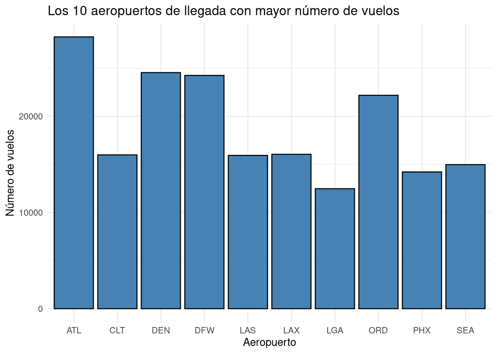

```r
top_airports <- flightData %>%
  group_by(DEST) %>%
  summarise(FlightCount = n()) %>%
  arrange(desc(FlightCount)) %>%
  top_n(10, FlightCount)

ggplot(top_airports, aes(x = DEST, y = FlightCount)) +
  geom_bar(stat = "identity", fill = "steelblue", color = "black") +
  theme_minimal() +
  labs(x = "Aeropuerto", y = "Número de vuelos",
       title = "Los 10 aeropuertos de llegada con mayor número de vuelos")
```

Como era de esperar, `ATL`, `DEN` y `DFW` también son los aeropuertos con más vuelos de llegada.

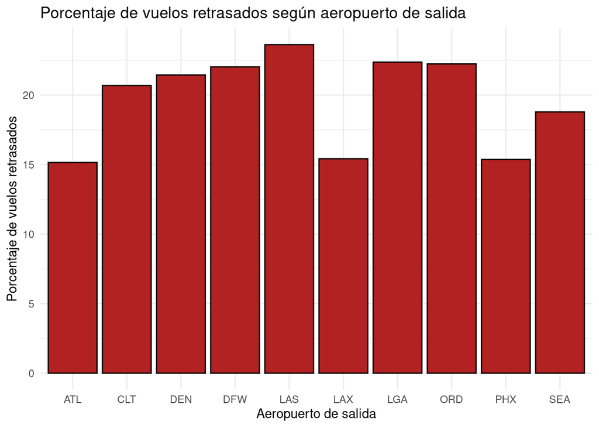

```r
percentage_delays <- flightData %>%
  group_by(ORIGIN) %>%
  summarise(FlightCount = n(),
            Percentage_Delayed = mean(ARR_DEL15, na.rm = TRUE) * 100) %>%
  arrange(desc(FlightCount)) %>%
  top_n(10, FlightCount)

ggplot(percentage_delays, aes(x = ORIGIN, y = Percentage_Delayed)) +
  geom_bar(stat = "identity", fill = "firebrick", color = "black") +
  labs(x = "Aeropuerto de salida", y = "Porcentaje de vuelos retrasados",
       title = "Porcentaje de vuelos retrasados según aeropuerto de salida") +
  theme_minimal()
```

Entre los diez aeropuertos con más vuelos de salida, Atlanta (`ATL`), Los Ángeles (`LAX`) y Phoenix (`PHX`) tienen los menores porcentajes de retrasos, mientras que Las Vegas (`LAS`) registra el mayor porcentaje.

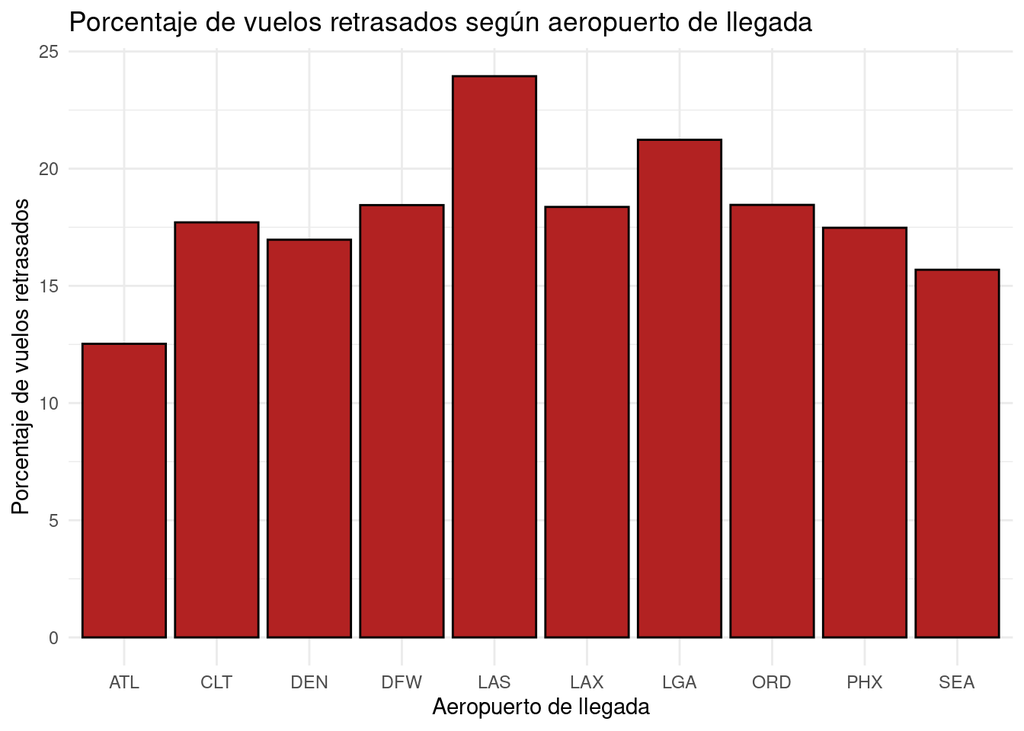

```r
percentage_delays <- flightData %>%
  group_by(DEST) %>%
  summarise(FlightCount = n(),
            Percentage_Delayed = mean(ARR_DEL15, na.rm = TRUE) * 100) %>%
  arrange(desc(FlightCount)) %>%
  top_n(10, FlightCount)

ggplot(percentage_delays, aes(x = DEST, y = Percentage_Delayed)) +
  geom_bar(stat = "identity", fill = "firebrick", color = "black") +
  labs(x = "Aeropuerto de llegada", y = "Porcentaje de vuelos retrasados",
       title = "Porcentaje de vuelos retrasados según aeropuerto de llegada") +
  theme_minimal()
```

## 4.4 Análisis por hora programada de salida y llegada (parte 1)

Pasamos a mirar las variables continuas.

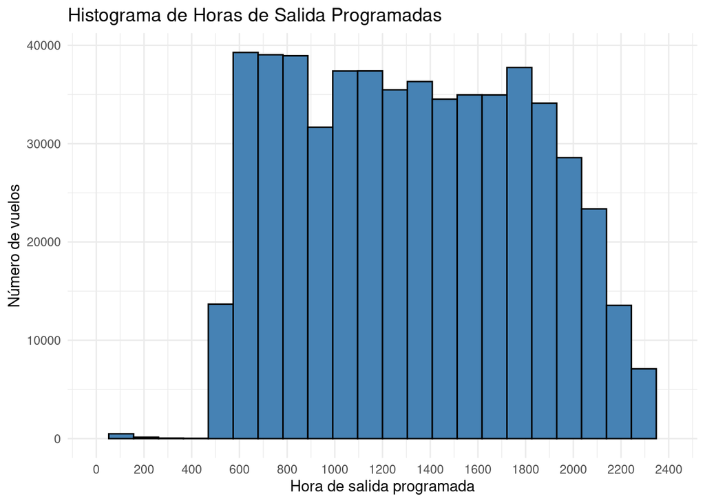

```r
ggplot(flightData, aes(x = CRS_DEP_TIME)) +
  geom_histogram(bins = 24, fill = "steelblue", color = "black") +
  scale_x_continuous(breaks = seq(0, 2400, by = 200), limits = c(0, 2400)) +
  labs(x = "Hora de salida programada",
       y = "Número de vuelos",
       title = "Histograma de Horas de Salida Programadas") +
  theme_minimal()
```

El análisis de las horas de salida programadas revela que los vuelos son mucho menos frecuentes durante la madrugada (00:00–05:00).

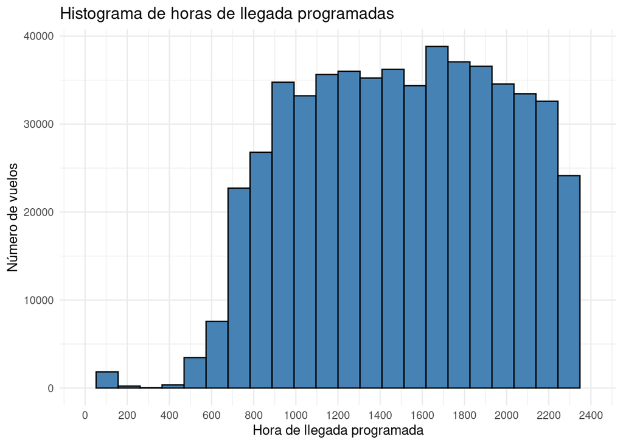

```r
ggplot(flightData, aes(x = CRS_ARR_TIME)) +
  geom_histogram(bins = 24, fill = "steelblue", color = "black") +
  scale_x_continuous(breaks = seq(0, 2400, by = 200), limits = c(0, 2400)) +
  labs(x = "Hora de llegada programada",
       y = "Número de vuelos",
       title = "Histograma de horas de llegada programadas") +
  theme_minimal()
```

Similar al patrón de salidas, los vuelos de llegada también son menos frecuentes en horas tempranas, pero con una distribución que tiende a centrarse más tarde en el día.

## 4.5 Análisis por duración programada (parte 1)

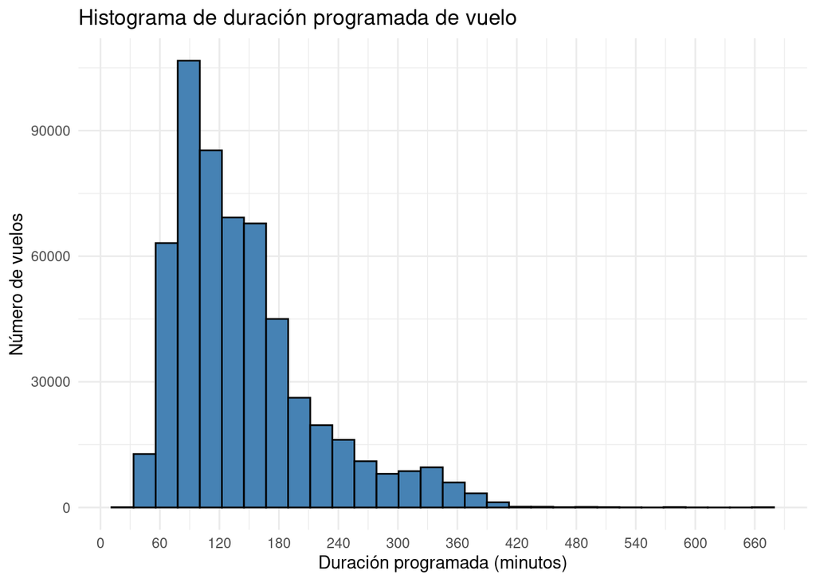

```r
ggplot(flightData, aes(x = CRS_ELAPSED_TIME)) +
  geom_histogram(bins = 30, fill = "steelblue", color = "black") +
  scale_x_continuous(breaks = seq(0, max(flightData$CRS_ELAPSED_TIME, na.rm = TRUE), by = 60)) +
  labs(x = "Duración programada (minutos)",
       y = "Número de vuelos",
       title = "Histograma de duración programada de vuelo") +
  theme_minimal()
```

La duración programada de la mayoría de los vuelos oscila entre 1 y 7 horas (60 a 420 minutos). Sin embargo, se observan algunos valores atípicos, especialmente vuelos con duraciones superiores a 11 horas (660 minutos).

```r
flightData %>%
  arrange(desc(CRS_ELAPSED_TIME)) %>%
  head(10)
```

```
##    DAY_OF_WEEK    FL_DATE OP_UNIQUE_CARRIER ORIGIN DEST CRS_DEP_TIME DEP_TIME
## 1        lunes 2023-09-04 Hawaiian Airlines    BOS  HNL          800     1033
## 2        lunes 2023-09-11 Hawaiian Airlines    BOS  HNL          800      807
## 3        lunes 2023-09-18 Hawaiian Airlines    BOS  HNL          800      759
## 4        lunes 2023-09-25 Hawaiian Airlines    BOS  HNL          800      759
## 5       martes 2023-09-05 Hawaiian Airlines    BOS  HNL          800      803
## 6       martes 2023-09-12 Hawaiian Airlines    BOS  HNL          800      102
## 7       martes 2023-09-19 Hawaiian Airlines    BOS  HNL          800      831
## 8       martes 2023-09-26 Hawaiian Airlines    BOS  HNL          800      827
## 9       jueves 2023-09-07 Hawaiian Airlines    BOS  HNL          800      757
## 10      jueves 2023-09-14 Hawaiian Airlines    BOS  HNL          800      803
##    DEP_DELAY_NEW CRS_ARR_TIME ARR_TIME ARR_DELAY_NEW ARR_DEL15 CRS_ELAPSED_TIME
## 1            153         1310     1533           143         1              670
## 2              7         1310     1337            27         1              670
## 3              0         1310     1239             0         0              670
```

[output cut: 18 more lines]

Al investigar estos valores atípicos, se descubre que corresponden a vuelos de larga distancia, como los de Boston a Hawaii, justificando así su extensa duración.

## 4.6 Análisis por distancia

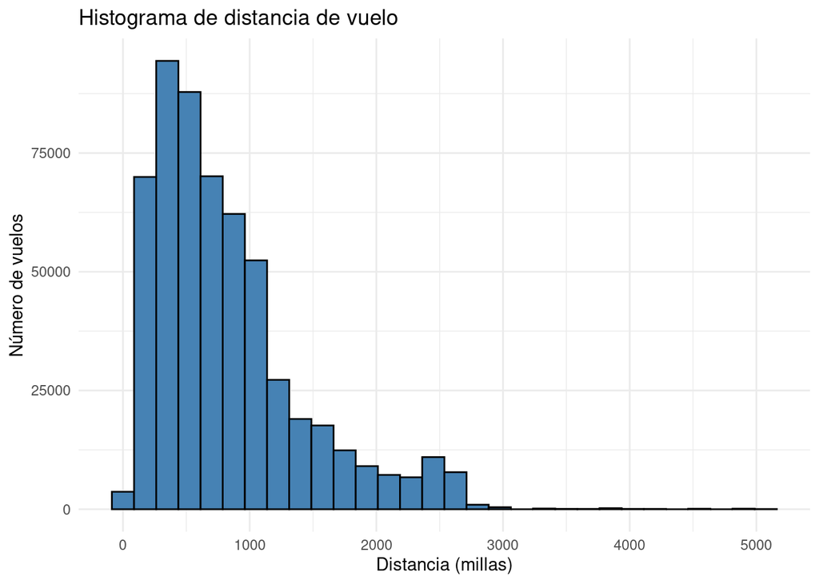

```r
ggplot(flightData, aes(x = DISTANCE)) +
  geom_histogram(bins = 30, fill = "steelblue", color = "black") +
  labs(x = "Distancia (millas)",
       y = "Número de vuelos",
       title = "Histograma de distancia de vuelo") +
  theme_minimal()
```

El análisis de la distancia de los vuelos muestra un patrón similar al de la duración. Los valores extremos, nuevamente, corresponden principalmente a rutas de larga distancia hacia destinos como Hawaii.

# 5 Discretización de atributos

Para mejorar la flexibilidad en la fase de modelización y obtener insights más detallados, decidimos discretizar algunas variables.

## 5.1 Discretización de horas programadas de salida y llegada

Convertimos las horas programadas de salida y llegada en categorías discretas. Esto se hace dividiendo el día en intervalos de una hora, como “00:00-00:59”, “01:00-01:59”, etc.

```r
breaks <- seq(from = 0, to = 2400, by = 100)

labels <- c("00:00-00:59", "01:00-01:59", "02:00-02:59", "03:00-03:59",
            "04:00-04:59", "05:00-05:59", "06:00-06:59", "07:00-07:59",
            "08:00-08:59", "09:00-09:59", "10:00-10:59", "11:00-11:59",
            "12:00-12:59", "13:00-13:59", "14:00-14:59", "15:00-15:59",
            "16:00-16:59", "17:00-17:59", "18:00-18:59", "19:00-19:59",
            "20:00-20:59", "21:00-21:59", "22:00-22:59", "23:00-23:59")

flightData$CRS_DEP_TIME_DISCRETE <- cut(flightData$CRS_DEP_TIME,
                                        breaks = breaks,
                                        include.lowest = TRUE,
                                        labels = labels)
flightData$CRS_ARR_TIME_DISCRETE <- cut(flightData$CRS_ARR_TIME,
                                        breaks = breaks,
                                        include.lowest = TRUE,
                                        labels = labels)

levels(flightData$CRS_DEP_TIME_DISCRETE)
```

```
##  [1] "00:00-00:59" "01:00-01:59" "02:00-02:59" "03:00-03:59" "04:00-04:59"
##  [6] "05:00-05:59" "06:00-06:59" "07:00-07:59" "08:00-08:59" "09:00-09:59"
## [11] "10:00-10:59" "11:00-11:59" "12:00-12:59" "13:00-13:59" "14:00-14:59"
## [16] "15:00-15:59" "16:00-16:59" "17:00-17:59" "18:00-18:59" "19:00-19:59"
## [21] "20:00-20:59" "21:00-21:59" "22:00-22:59" "23:00-23:59"
```

```r
levels(flightData$CRS_ARR_TIME_DISCRETE)
```

```
##  [1] "00:00-00:59" "01:00-01:59" "02:00-02:59" "03:00-03:59" "04:00-04:59"
##  [6] "05:00-05:59" "06:00-06:59" "07:00-07:59" "08:00-08:59" "09:00-09:59"
## [11] "10:00-10:59" "11:00-11:59" "12:00-12:59" "13:00-13:59" "14:00-14:59"
## [16] "15:00-15:59" "16:00-16:59" "17:00-17:59" "18:00-18:59" "19:00-19:59"
## [21] "20:00-20:59" "21:00-21:59" "22:00-22:59" "23:00-23:59"
```

## 5.2 Análisis por hora programada de salida y llegada (parte 2)

A continuación, analizamos el porcentaje de vuelos retrasados en cada franja horaria.

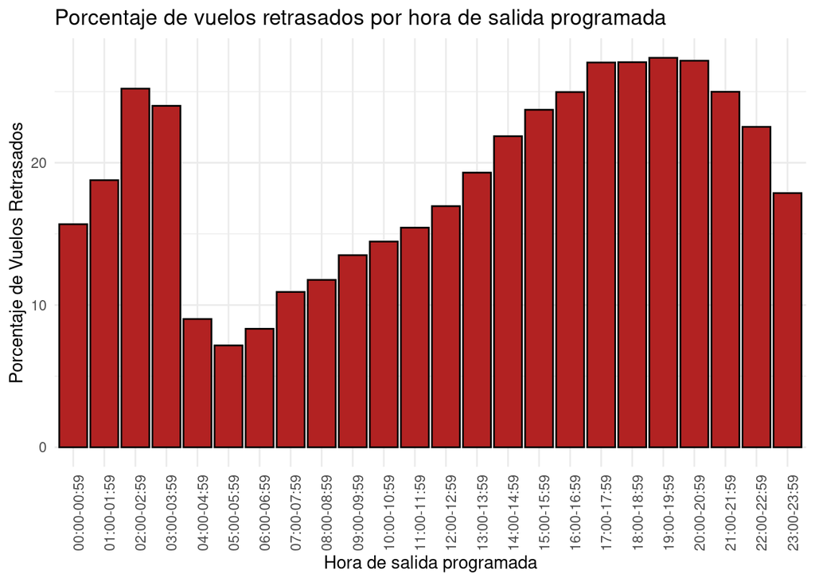

```r
percentage_delays <- flightData %>%
  group_by(CRS_DEP_TIME_DISCRETE) %>%
  summarise(Percentage_Delayed = mean(ARR_DEL15) * 100)

ggplot(percentage_delays, aes(x = CRS_DEP_TIME_DISCRETE, y = Percentage_Delayed)) +
  geom_bar(stat = "identity", fill = "firebrick", color = "black") +
  labs(x = "Hora de salida programada", y = "Porcentaje de Vuelos Retrasados",
       title = "Porcentaje de vuelos retrasados por hora de salida programada") +
  theme_minimal() +
  theme(axis.text.x = element_text(angle = 90))
```

Al estudiar el porcentaje de vuelos retrasados por cada franja horaria, observamos patrones interesantes:

- Los vuelos que salen entre las 05:00 y 05:59 presentan el menor retraso (7.2 %), lo que podría atribuirse a una menor congestión aérea en las primeras horas del día.
- Por el contrario, los vuelos con salida entre las 19:00 y 19:59 registran el mayor porcentaje de retrasos (27.4 %). Esto se podría explicar por el efecto acumulativo de retrasos anteriores durante el día.

Curiosamente, hay un aumento inesperado en los retrasos entre la 01:00 y 03:59, lo que podría deberse a la menor cantidad de vuelos y, por tanto, a una muestra más pequeña que podría distorsionar las estadísticas.

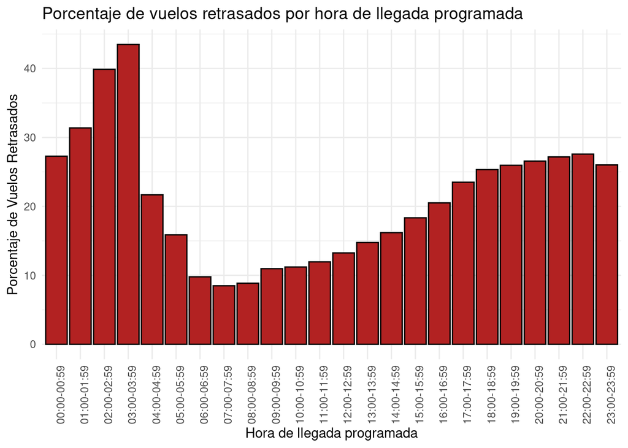

```r
percentage_delays <- flightData %>%
  group_by(CRS_ARR_TIME_DISCRETE) %>%
  summarise(Percentage_Delayed = mean(ARR_DEL15) * 100)

ggplot(percentage_delays, aes(x = CRS_ARR_TIME_DISCRETE, y = Percentage_Delayed)) +
  geom_bar(stat = "identity", fill = "firebrick", color = "black") +
  labs(x = "Hora de llegada programada", y = "Porcentaje de Vuelos Retrasados",
       title = "Porcentaje de vuelos retrasados por hora de llegada programada") +
  theme_minimal() +
  theme(axis.text.x = element_text(angle = 90))
```

Los patrones de retraso en las horas de llegada son similares a los de las salidas, con un incremento general a lo largo del día. Los vuelos que llegan entre las 07:00 y 07:59 tienen menos retrasos (8.5 %), mientras que aquellos programados para llegar entre las 03:00 y 03:59 muestran un elevado porcentaje de retrasos (43.5 %), lo que podría estar influenciado por el mismo factor de muestra reducida durante las horas nocturnas.

## 5.3 Discretización de duración del vuelo

Para discretizar la variable `CRS_ELAPSED_TIME`, empleamos el método de *k*-means.

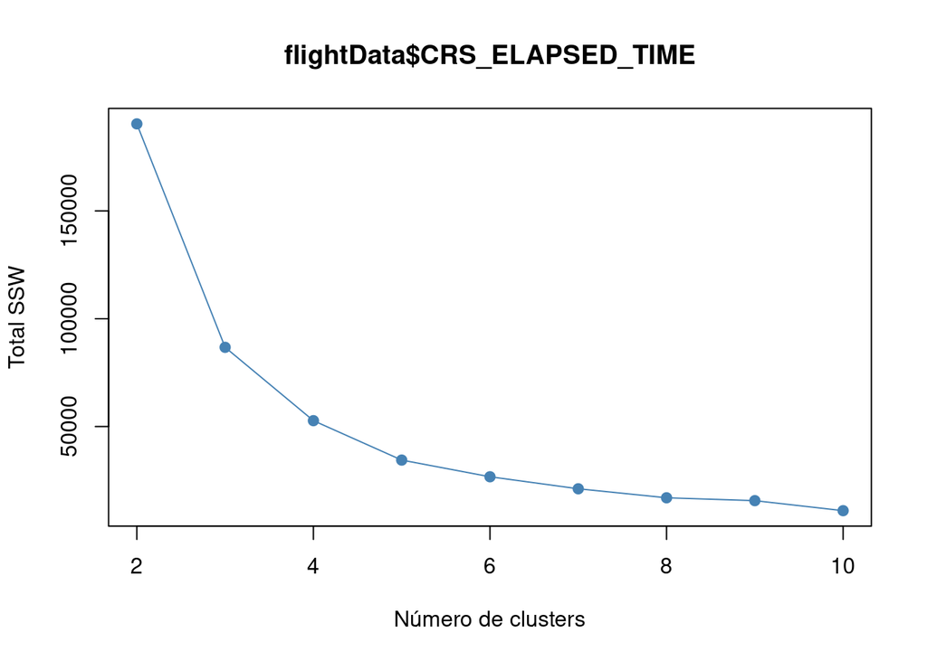

```r
resultados <- rep(0, 10)

for (i in 2:10) {
  set.seed(123)
  fit <- kmeans(scale(flightData$CRS_ELAPSED_TIME), centers = i)
  resultados[i] <- fit$tot.withinss
}

plot(2:10, resultados[2:10], type = "o", col = "steelblue", pch = 19,
     xlab = "Número de clusters", ylab = "Total SSW", main = "flightData$CRS_ELAPSED_TIME")
```

Tras analizar diferentes números de clústeres, determinamos que el óptimo parece estar entre 4 y 5, ya que es en este punto donde la curva comienza a estabilizarse.

```r
library(arules)

set.seed(123)
flightData$CRS_ELAPSED_TIME_DISCRETE <- discretize(flightData$CRS_ELAPSED_TIME,
                                                   method = "cluster",
                                                   breaks = 5)
summary(flightData$CRS_ELAPSED_TIME_DISCRETE)
```

```
##  [24,98.7) [98.7,144)  [144,204)  [204,289)  [289,670]
##     172873     161473     134859      57835      33847
```

*k*-means ha formado 5 clústers para la duración programada de los vuelos:

- Vuelo muy cortos: 24-99 minutos
- Vuelos cortos: 99-144 minutos
- Vuelos intermedios: 144-204 minutos
- Vuelos largos: 204-289 minutos
- Vuelos muy largos: 289-670 minutos

## 5.4 Análisis por duración programada (parte 2)

Con las categorías definidas, procedemos a analizar cómo la duración del vuelo afecta el porcentaje de retrasos.

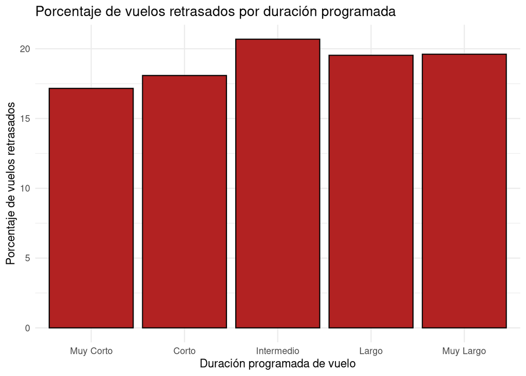

```r
levels(flightData$CRS_ELAPSED_TIME_DISCRETE) <- c("Muy Corto", "Corto", "Intermedio", "Largo", "Muy Largo")

percentage_delays <- flightData %>%
  group_by(CRS_ELAPSED_TIME_DISCRETE) %>%
  summarise(Percentage_Delayed = mean(ARR_DEL15) * 100)

ggplot(percentage_delays, aes(x = CRS_ELAPSED_TIME_DISCRETE, y = Percentage_Delayed)) +
  geom_bar(stat = "identity", fill = "firebrick", color = "black") +
  labs(x = "Duración programada de vuelo", y = "Porcentaje de vuelos retrasados",
       title = "Porcentaje de vuelos retrasados por duración programada") +
  theme_minimal()
```

Los resultados muestran que hay una variación ligera en los retrasos en función de la duración programada del vuelo. Los vuelos muy cortos y cortos (24-144 minutos) suelen retrasarse menos que los vuelos de mayor duración. Los vuelos de menor duración podrían ser menos susceptibles a factores que causan retrasos, como la congestión en los aeropuertos o las complicaciones logísticas.

# 6 Transformación de la hora del día

Para preparar nuestros datos para la fase de modelado, es importante modificar el formato de las columnas que representan la hora del día. Dado que cada hora solo tiene valores de 00 a 59 minutos, dejando un intervalo sin usar entre 60 y 99, transformamos estas horas a un formato continuo en minutos desde medianoche.

```r
convert_time_to_minutes <- function(time) {
  hours <- time %/% 100
  minutes <- time %% 100
  return(hours * 60 + minutes)
}

flightData$CRS_DEP_TIME_CONTINUOUS <- convert_time_to_minutes(flightData$CRS_DEP_TIME)
flightData$CRS_ARR_TIME_CONTINUOUS <- convert_time_to_minutes(flightData$CRS_ARR_TIME)

head(flightData[,c("CRS_DEP_TIME_CONTINUOUS", "CRS_ARR_TIME_CONTINUOUS")])
```

```
##   CRS_DEP_TIME_CONTINUOUS CRS_ARR_TIME_CONTINUOUS
## 1                     414                     540
## 2                     762                     890
## 3                    1047                    1178
## 4                     455                     528
## 5                     845                     912
## 6                     370                     539
```

# 7 Análisis de correlaciones

Aunque nuestra variable dependiente (`ARR_DEL15`) es binaria, exploramos cómo las variables numéricas están relacionadas con la duración del retraso (`ARR_DELAY_NEW`).

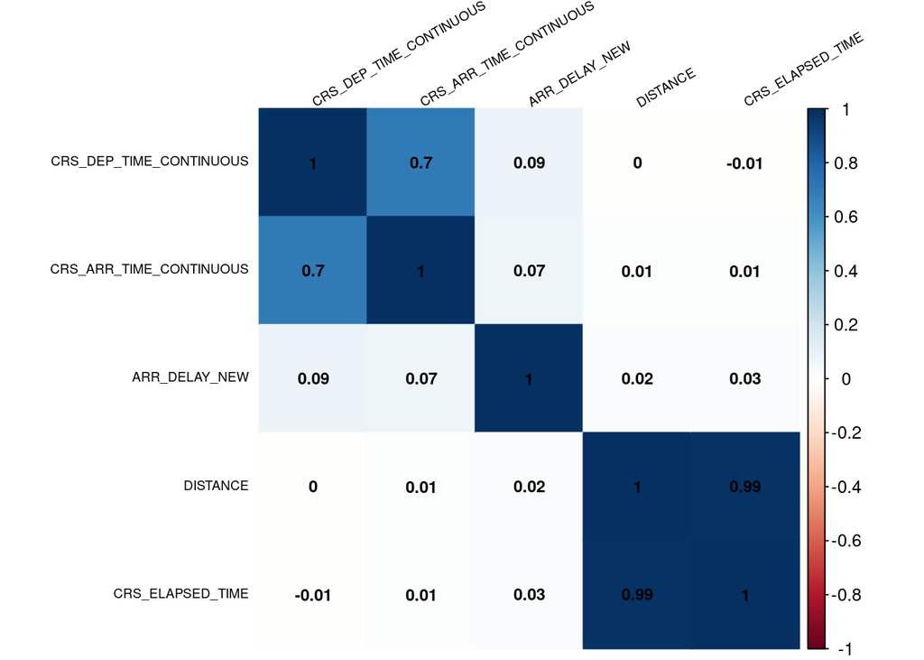

```r
library(corrplot)

n = c("ARR_DELAY_NEW", "CRS_ELAPSED_TIME", "DISTANCE",
      "CRS_DEP_TIME_CONTINUOUS", "CRS_ARR_TIME_CONTINUOUS")

factores = flightData %>% select(all_of(n))
res <- cor(factores)
corrplot(res, method="color", tl.col="black", tl.srt=30, order="AOE",
         tl.cex=0.6, number.cex=0.75, sig.level=0.01, addCoef.col="black")
```

Nuestro análisis revela que ninguna de las variables numéricas muestra una correlación lineal fuerte (superior a 0.09) con `ARR_DELAY_NEW`. Aunque esto sugiere la ausencia de una relación lineal directa, no descarta la posibilidad de relaciones no lineales. Anteriormente observamos que el porcentaje de vuelos retrasados varía según la hora de salida y llegada, tendiendo a disminuir por la mañana y aumentar por la tarde.

Por otro lado, encontramos una correlación casi perfecta (0.99) entre `DISTANCE` y `CRS_ELAPSED_TIME`. Esto indica una redundancia en la información proporcionada por estas dos variables. Para evitar la inclusión de datos redundantes y mejorar la precisión de nuestro modelo, optamos por eliminar la variable `DISTANCE` del conjunto de datos.

```r
flightData$DISTANCE <- NULL
str(flightData)
```

```
## 'data.frame':    560887 obs. of  19 variables:
##  $ DAY_OF_WEEK              : Factor w/ 7 levels "lunes","martes",..: 1 1 1 1 1 1 1 1 1 1 ...
##  $ FL_DATE                  : Date, format: "2023-09-04" "2023-09-04" ...
##  $ OP_UNIQUE_CARRIER        : Factor w/ 15 levels "Endeavor Air",..: 1 1 1 1 1 1 1 1 1 1 ...
##  $ ORIGIN                   : Factor w/ 340 levels "ABE","ABI","ABQ",..: 1 1 1 5 5 12 12 13 15 15 ...
##  $ DEST                     : Factor w/ 340 levels "ABE","ABI","ABQ",..: 21 21 21 21 21 21 21 21 99 190 ...
##  $ CRS_DEP_TIME             : int  654 1242 1727 735 1405 610 1620 1015 1245 706 ...
##  $ DEP_TIME                 : int  649 1237 1717 725 1400 609 1636 1010 1237 701 ...
##  $ DEP_DELAY_NEW            : num  0 0 0 0 0 0 16 0 0 0 ...
##  $ CRS_ARR_TIME             : int  900 1450 1938 848 1512 859 1906 1123 1428 803 ...
##  $ ARR_TIME                 : int  842 1431 1905 820 1454 904 1913 1100 1411 759 ...
##  $ ARR_DELAY_NEW            : num  0 0 0 0 0 5 7 0 0 0 ...
##  $ ARR_DEL15                : num  0 0 0 0 0 0 0 0 0 0 ...
##  $ CRS_ELAPSED_TIME         : num  126 128 131 73 67 109 106 68 103 57 ...
##  $ ACTUAL_ELAPSED_TIME      : num  113 114 108 55 54 115 97 50 94 58 ...
##  $ CRS_DEP_TIME_DISCRETE    : Factor w/ 24 levels "00:00-00:59",..: 7 13 18 8 15 7 17 11 13 8 ...
##  $ CRS_ARR_TIME_DISCRETE    : Factor w/ 24 levels "00:00-00:59",..: 9 15 20 9 16 9 20 12 15 9 ...
##  $ CRS_ELAPSED_TIME_DISCRETE: Factor w/ 5 levels "Muy Corto","Corto",..: 2 2 2 1 1 2 2 1 2 1 ...
##   ..- attr(*, "discretized:breaks")= num [1:6] 24 98.7 143.9 203.6 288.6 ...
##   ..- attr(*, "discretized:method")= chr "cluster"
##  $ CRS_DEP_TIME_CONTINUOUS  : num  414 762 1047 455 845 ...
##  $ CRS_ARR_TIME_CONTINUOUS  : num  540 890 1178 528 912 ...
```

# 8 Análisis SVD

En nuestro análisis SVD, las limitaciones de hardware nos llevan a seleccionar cuidadosamente nuestras variables. Para evitar la sobrecarga de 680 variables dummy derivadas de 340 aeropuertos de salida y llegada, optamos por incluir solo un subconjunto de variables.

Incorporamos las tres variables numéricas:

1. **CRS_ELAPSED_TIME**: Duración programada del vuelo.
2. **CRS_DEP_TIME_CONTINUOUS**: Hora de salida, convertida a minutos desde medianoche.
3. **CRS_ARR_TIME_CONTINUOUS**: Hora de llegada en el mismo formato.

En cuanto a las categóricas, seleccionamos solo las aerolíneas (`OP_UNIQUE_CARRIER`) y los días de la semana (`DAY_OF_WEEK`), resultando en 15 dummies para las aerolíneas y 7 para los días de la semana.

El conjunto final para SVD incluye estas 25 variables (numéricas y categóricas). Utilizamos `fastDummies` para las variables dummy y `scale` para las numéricas. Combinamos estos datos y aplicamos SVD, buscando descubrir patrones y relaciones significativas en los datos de vuelo.

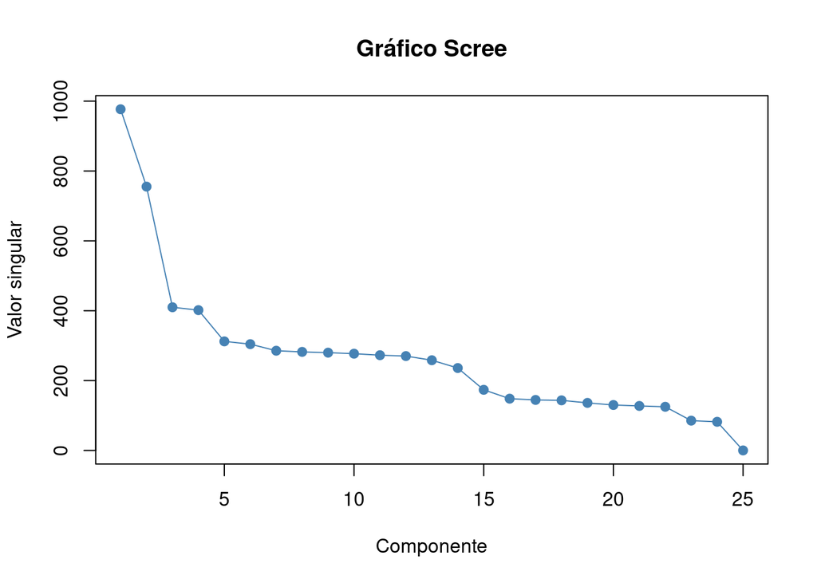

```r
library(fastDummies)

# Transformamos las columnas categóricas en variables dummy y eliminamos las columnas originales
dummy_data <- flightData %>%
  select(DAY_OF_WEEK, OP_UNIQUE_CARRIER) %>%
  dummy_cols(remove_selected_columns = TRUE)

# Normalizamos las variables numéricas
numeric_data <- flightData %>%
  select(CRS_ELAPSED_TIME, CRS_DEP_TIME_CONTINUOUS, CRS_ARR_TIME_CONTINUOUS) %>%
  scale()

# Unimos los datos numéricos y dummy en un solo conjunto de datos
Z <- cbind(numeric_data, dummy_data)

# Aplicamos SVD al conjunto de datos combinado
svd_results <- svd(Z)

# Obtenemos los valores singulares del resultado de SVD
singular_values <- svd_results$d

# Mostramos los valores singulares para identificar componentes importantes
plot(singular_values, type = "o", col = "steelblue", pch = 19,
     xlab = "Componente",
     ylab = "Valor singular",
     main = "Gráfico Scree")
```

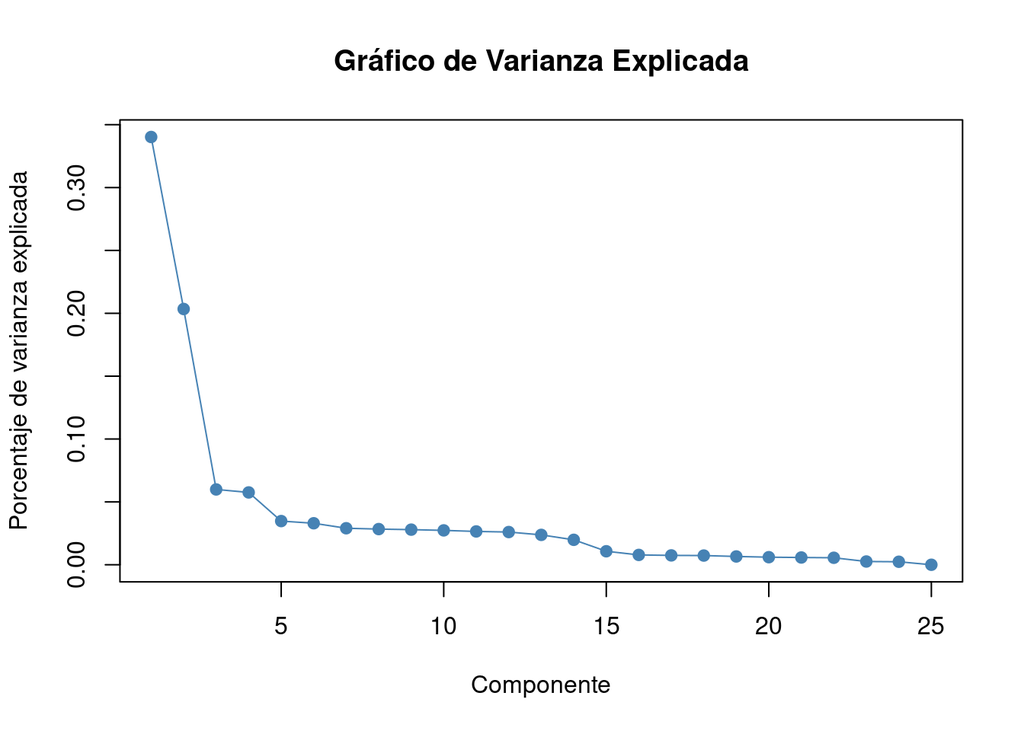

```r
# Determinamos la varianza explicada por cada componente
total_variance <- sum(singular_values^2)
explained_variance <- singular_values^2 / total_variance

# Visualizamos el porcentaje de varianza explicada por cada componente
plot(explained_variance, type = "o", col = "steelblue", pch = 19,
     xlab = "Componente",
     ylab = "Porcentaje de varianza explicada",
     main = "Gráfico de Varianza Explicada")
```

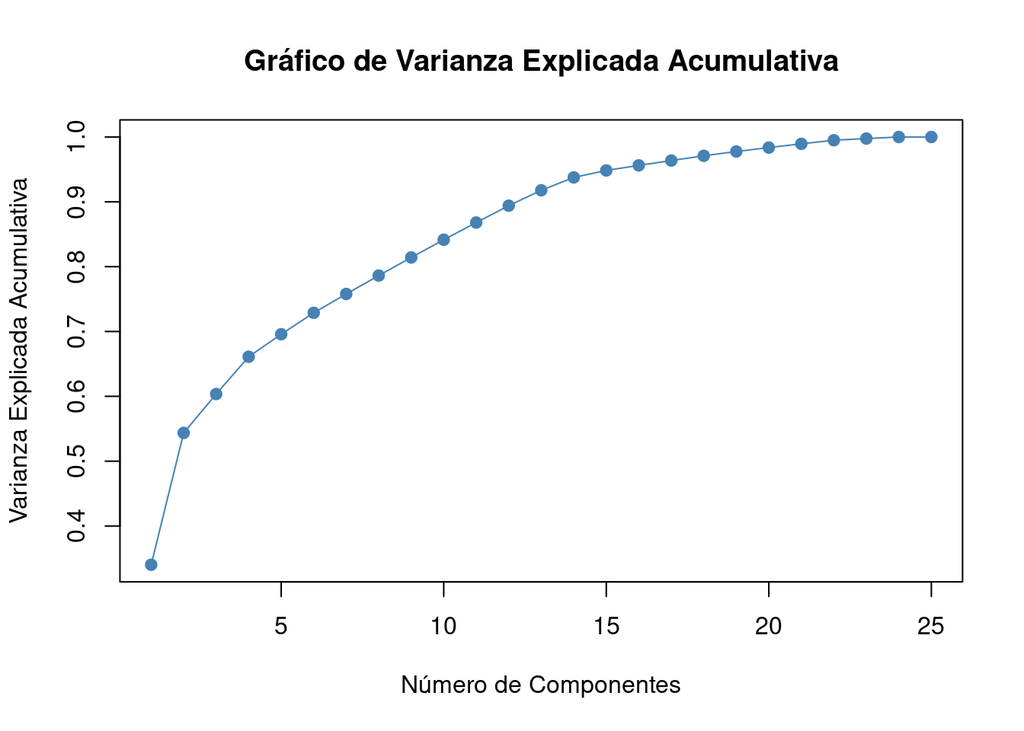

```r
# Calculamos la varianza acumulada
cum_explained_variance <- cumsum(singular_values^2) / total_variance

# Mostramos la varianza explicada acumulativa
plot(cum_explained_variance, type = "o", col = "steelblue", pch = 19,
     xlab = "Número de Componentes",
     ylab = "Varianza Explicada Acumulativa",
     main = "Gráfico de Varianza Explicada Acumulativa")
```

En el análisis del gráfico Scree, identificamos un “codo” evidente después de solo 2 componentes, que explican el 54.4% de la varianza total. Sin embargo, para capturar el 90% de la varianza, necesitamos incluir hasta 13 componentes, los cuales explican juntos el 91.8% de la varianza. Esto indica que, utilizando poco más de la mitad de las variables originales, podemos representar más del 90% de la información contenida en los datos.

## 8.1 Análisis de los componentes

La matriz *V* es una de las tres matrices resultantes de la descomposición SVD. Cada columna de esta matriz representa un componente singular y sus elementos muestran cómo cada variable original contribuye a ese componente. En otras palabras, nos ayuda a comprender la importancia relativa de nuestras variables originales en cada uno de los componentes singulares identificados.

Mostramos los primeros 3 componentes de la matriz para analizar y entender mejor su contribución individual a nuestro conjunto de datos:

```r
V_matrix <- svd_results$v
rownames(V_matrix) <- colnames(Z)
V_matrix[,1:3]
```

```
##                                               [,1]          [,2]         [,3]
## CRS_ELAPSED_TIME                      4.408865e-03  0.9904341623  0.019563729
## CRS_DEP_TIME_CONTINUOUS               7.070417e-01 -0.0199489208  0.698324100
## CRS_ARR_TIME_CONTINUOUS               7.070765e-01  0.0137610881 -0.698807490
## DAY_OF_WEEK_lunes                     1.407418e-03 -0.0026117424 -0.022209914
## DAY_OF_WEEK_martes                   -1.020687e-03 -0.0019490563 -0.039413284
## DAY_OF_WEEK_miércoles                 9.283873e-04 -0.0029047553 -0.036470128
## DAY_OF_WEEK_jueves                    1.590550e-03 -0.0031473120 -0.026577855
## DAY_OF_WEEK_viernes                   7.221105e-04 -0.0034934085 -0.034952167
## DAY_OF_WEEK_sábado                   -8.569530e-03  0.0071238869 -0.052742301
## DAY_OF_WEEK_domingo                   4.870448e-03  0.0010076946 -0.017174330
## OP_UNIQUE_CARRIER_Endeavor Air       -5.466181e-04 -0.0173703988 -0.004039178
## OP_UNIQUE_CARRIER_American Airlines  -1.251267e-03  0.0411476111 -0.051368873
## OP_UNIQUE_CARRIER_Alaska Airlines     1.965524e-03  0.0355451874 -0.009757398
## OP_UNIQUE_CARRIER_JetBlue Airways     5.775564e-04  0.0222105360  0.002500524
## OP_UNIQUE_CARRIER_Delta Air Lines    -4.758009e-04  0.0318305895 -0.013160560
## OP_UNIQUE_CARRIER_Frontier Airlines  -6.406396e-04  0.0056435151  0.017352744
## OP_UNIQUE_CARRIER_Allegiant Air       8.022591e-04 -0.0007363409 -0.005085856
## OP_UNIQUE_CARRIER_Hawaiian Airlines  -1.414108e-03 -0.0028548265 -0.001892994
## OP_UNIQUE_CARRIER_Envoy Air          -3.098291e-04 -0.0142784786 -0.007784804
## OP_UNIQUE_CARRIER_Spirit Airlines     9.898533e-04  0.0110818038  0.010013040
## OP_UNIQUE_CARRIER_PSA Airlines       -1.779205e-07 -0.0158793424 -0.004462580
## OP_UNIQUE_CARRIER_SkyWest Airlines   -2.457338e-04 -0.0694699233 -0.014391186
## OP_UNIQUE_CARRIER_United Airlines     6.524204e-04  0.0543075222 -0.033967331
## OP_UNIQUE_CARRIER_Southwest Airlines  3.839197e-04 -0.0700581207 -0.101495483
## OP_UNIQUE_CARRIER_Republic Airways   -5.586614e-04 -0.0170940267 -0.012000044
```

Dada la gran cantidad de variables, un gráfico facilitará la interpretación de estas contribuciones:

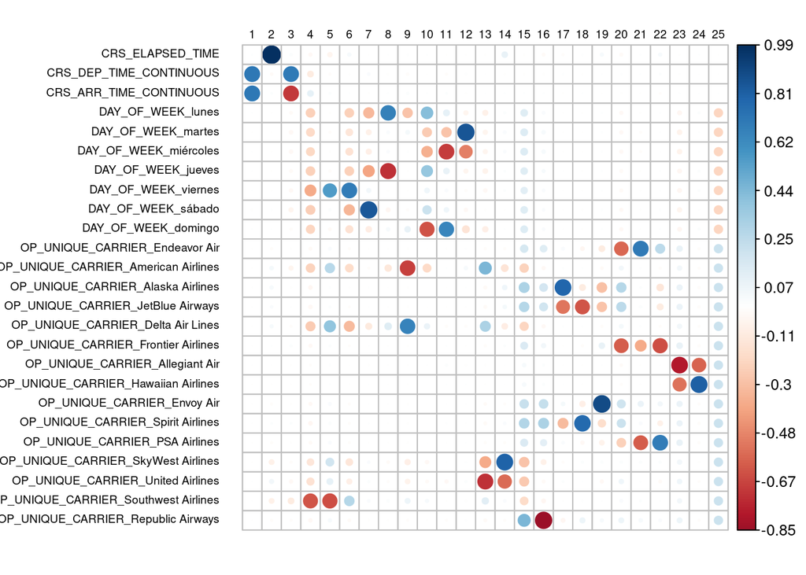

```r
corrplot(V_matrix, is.cor=FALSE, tl.cex=0.6, tl.srt=0, tl.offset=1, tl.col="black")
```

## 8.2 Interpretación de resultados

- **Componente 1**: Las variables `CRS_DEP_TIME_CONTINUOUS` y `ARR_TIME_CONTINUOUS` dominan este componente, ambos en la misma dirección. Esto sugiere que este componente refleja una relación directa entre las horas de salida y llegada.
- **Componente 2**: Se caracteriza por una influencia predominante de `CRS_ELAPSED_TIME`, lo que sugiere que este componente se enfoca principalmente en la duración del vuelo.
- **Componente 3**: En este caso, `CRS_DEP_TIME_CONTINUOUS` y `ARR_TIME_CONTINUOUS` también son significativos, pero con signos opuestos. Esto puede indicar que el componente está capturando situaciones en las que hay una diferencia significativa entre las horas de salida y llegada, como en los vuelos que salen por la noche (22h00) y llegan por la madrugada del día siguiente (00h30).
- **Del componente 4 en adelante**: Vemos una mayor contribución de variables como los días de la semana y las aerolíneas.

Algunas variables dummy, correspondientes a *Allegiant Air* y *Hawaiian Airlines*, no tienen representación directa hasta el componente 23. Aunque representan una proporción pequeña del total, es posible que nuestro modelo sea sesgado hacia las aerolíneas con mayor número de vuelos.

A continuación, exportamos el fichero CSV con los datos limpios.

```r
write.csv(flightData, '../data/flightData_clean.csv', row.names = FALSE)
```

# 9 Conclusiones

## 9.1 Resumen de hallazgos

Nuestro análisis exploratorio ha revelado patrones temporales claros en los retrasos de vuelos. Los vuelos que salen en las primeras horas de la mañana (05:00-05:59) suelen tener menos retrasos, mientras que aquellos en la tarde y noche muestran un aumento significativo. Esta tendencia podría deberse a la acumulación de retrasos a lo largo del día.

Identificamos diferencias notables en los porcentajes de retrasos entre aerolíneas y rutas. Aerolíneas como JetBlue mostraron mayores índices de retraso, mientras que Hawaiian Airlines registró los menores. Los aeropuertos con mayor tráfico, como Atlanta, Denver y Dallas Fort-Worth, también mostraron patrones distintos en términos de retrasos.

Hemos encontrado una correlación casi perfecta entre la distancia y el tiempo estimado del vuelo, lo que nos llevó a eliminar la variable `DISTANCE` para evitar redundancias en nuestro modelo.

Los resultados sugieren que los vuelos más cortos suelen tener menos retrasos en comparación con los vuelos más largos. Esto indica que los vuelos de menor duración podrían ser menos susceptibles a factores que causan retrasos.

## 9.2 Implicaciones para el modelado

El análisis SVD ha reducido la dimensionalidad de nuestro conjunto de datos, permitiéndonos representar la mayoría de la varianza con menos componentes. Esto nos ayudará a construir modelos de clasificación más eficientes y precisos.

La transformación de las horas de vuelo a un formato continuo en minutos desde medianoche facilitará el modelado y permitirá un análisis más preciso de la influencia temporal en los retrasos.

Dado que algunas variables dummy, como las correspondientes a ciertas aerolíneas, no aparecieron en los componentes principales hasta muy tarde en el análisis SVD, debemos ser conscientes de posibles sesgos en nuestro modelo hacia aerolíneas con mayor número de vuelos.

# 10 Bibliografía

Bureau of Transportation Statistics. (2023). *TranStats.* Recuperado de https://www.transtats.bts.gov/DL_SelectFields.aspx?gnoyr_VQ=FGJ&QO_fu146_anzr=b0-gvzr

GeeksforGeeks. (2023). *Dummy Variables in R Programming.* Recuperado de https://www.geeksforgeeks.org/dummy-variables-in-r-programming/

Gironés Roig, J. (2023). *Gestión de características.* Universitat Oberta de Catalunya.

Gironés Roig, J. (2023). *Modelos no supervisados.* Universitat Oberta de Catalunya.

Kaplan, J. & Schlegel, B. (2023). *fastDummies: Fast Creation of Dummy (Binary) Columns and Rows from Categorical Variables* (Versión 1.7.1). Recuperado de https://jacobkap.github.io/fastDummies/

Montoliu Colás, R. (2023). *Evaluación de modelos.* Universitat Oberta de Catalunya.

Montoliu Colás, R. (2023). *Preprocesado de datos.* Universitat Oberta de Catalunya.

Peng, R. D. (2023). *Dimension Reduction. En Exploratory Data Analysis.* Recuperado de https://bookdown.org/rdpeng/exdata/dimension-reduction.html

R Core Team. (2023). *Documentación sobre SVD.* Recuperado de https://www.rdocumentation.org/packages/base/versions/3.6.2/topics/svd